```r
library(zoo)
library(lubridate)
library(ggplot2)
setwd('C:/dersler/ie360')
```

# Introducing the Datasets

```r
cpi=read.csv(file = "cpi.csv")
cpi$Tarih=as.Date(as.yearmon(cpi$Tarih))
summary(cpi)
str(cpi)
```

```
     Tarih                cpival
 Min.   :2017-01-01   Min.   :299.7
 1st Qu.:2018-03-24   1st Qu.:341.2
 Median :2019-06-16   Median :416.4
 Mean   :2019-06-16   Mean   :424.9
 3rd Qu.:2020-09-08   3rd Qu.:479.8
 Max.   :2021-12-01   Max.   :687.0
```

```
'data.frame':	60 obs. of  2 variables:
 $ Tarih : Date, format: "2017-01-01" "2017-02-01" ...
 $ cpival: num  300 302 305 309 311 ...
```

The first dataset was cpi. Tarih column's format was changed to Date type, the same thing was applied to all other datasets.

```r
housing=read.csv(file = "housing_index.csv")
housing$Tarih=as.Date(as.yearmon(housing$Tarih))
summary(housing)
str(housing)
```

```
     Tarih               TPHKFE01
 Min.   :2017-01-01   Min.   : 95.5
 1st Qu.:2018-04-01   1st Qu.:107.1
 Median :2019-07-01   Median :112.4
 Mean   :2019-07-02   Mean   :132.1
 3rd Qu.:2020-10-01   3rd Qu.:149.9
 Max.   :2022-01-01   Max.   :279.7
```

```
'data.frame':	61 obs. of  2 variables:
 $ Tarih   : Date, format: "2017-01-01" "2017-02-01" ...
 $ TPHKFE01: num  95.5 96.7 97.9 98.7 99.8 ...
```

```r
purchases=read.csv(file = "purchases.csv",row.names= NULL,stringsAsFactors = FALSE)
purchases$Date=as.Date(as.yearmon(purchases$Date))
summary(purchases)
str(purchases)
```

```
      Date            Total.Electronic.Purchases
 Min.   :2017-01-01   Min.   : 7962144
 1st Qu.:2018-03-24   1st Qu.:10115958
 Median :2019-06-16   Median :12425920
 Mean   :2019-06-16   Mean   :15463223
 3rd Qu.:2020-09-08   3rd Qu.:19466956
 Max.   :2021-12-01   Max.   :36364947
```

```
'data.frame':	60 obs. of  2 variables:
 $ Date                      : Date, format: "2017-01-01" "2017-02-01" ...
 $ Total.Electronic.Purchases: int  7962144 8496843 10922269 8665710 8812552 10675900 8524348 8566857 11159324 9385539 ...
```

# Visualisation of Datasets

## Customer Price Index Histogram

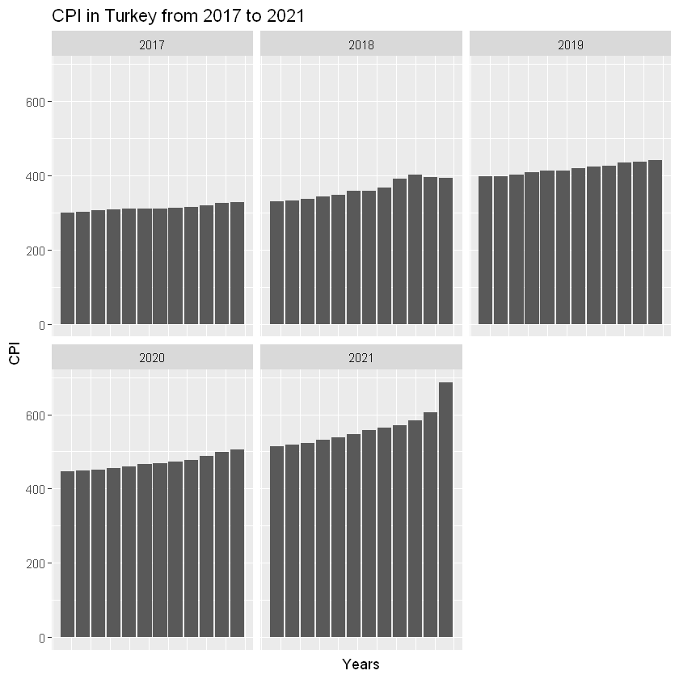

```r
ggplot(data=cpi, aes(x=month(Tarih), y=cpival))+geom_bar(stat='identity')+
    facet_wrap(~year(Tarih))+
    theme(legend.position = "none",
         axis.ticks.x=element_blank(),
         axis.text.x= element_blank())+
    xlab("Years") + ylab("CPI")+ ggtitle("CPI in Turkey from 2017 to 2021")
```

A gradual increase can be seen throughout the span of 5 years. However, the rate of increase saw a boost in the last 2 years, with the last datapoint being the current peak (likely to be toppled soon).

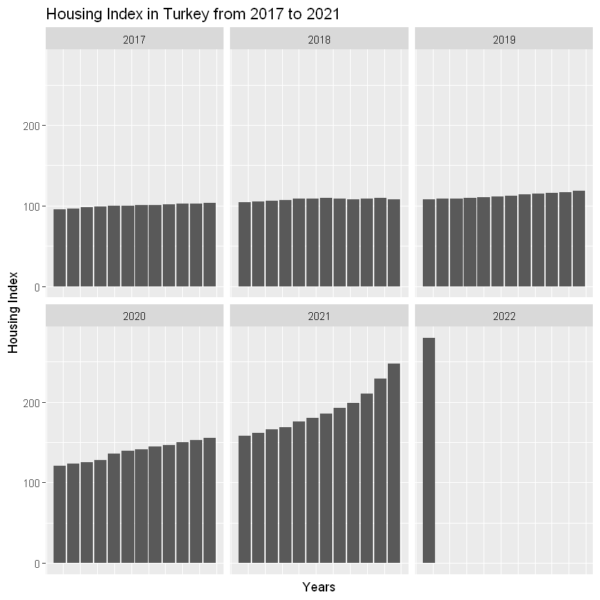

```r
ggplot(data=housing, aes(x=month(Tarih), y=TPHKFE01))+geom_bar(stat='identity')+
    facet_wrap(~year(Tarih))+
    theme(legend.position = "none",
         axis.ticks.x=element_blank(),
         axis.text.x= element_blank())+
    xlab("Years") + ylab("Housing Index")+ ggtitle("Housing Index in Turkey from 2017 to 2021")
```

The Housing index can be said to be relatively stagnant until the year 2020. the apparent divergence can be explained by the pandemic coupled by the increase in the price of producer goods.

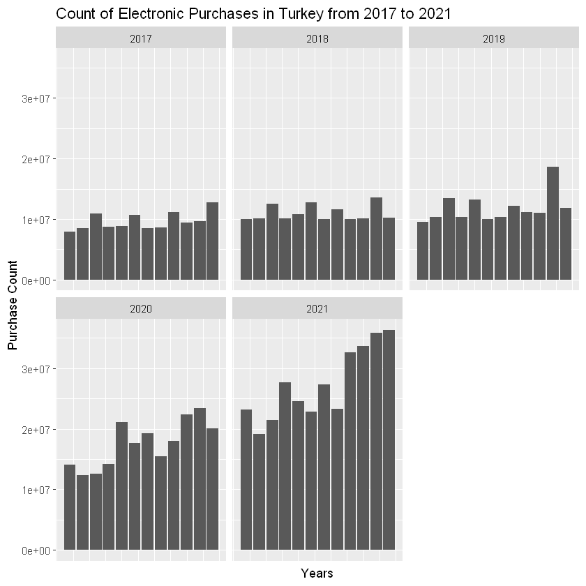

```r
ggplot(data=purchases, aes(x=month(Date), y=Total.Electronic.Purchases))+geom_bar(stat='identity')+
    facet_wrap(~year(Date))+
    theme(legend.position = "none",
         axis.ticks.x=element_blank(),
         axis.text.x= element_blank())+
    xlab("Years") + ylab("Purchase Count")+ ggtitle("Count of Electronic Purchases in Turkey from 2017 to 2021")
```

Like the other datasets, count of electronic purchases also saw an increase, especially after 2020. The reasons could include pandemic circumstances forcing people to adapt to the digital world. This can be said to be a significant reason that drove the boost in spite of the rise in prices and fall in purchasing power of the general public.

# Visualisation of Searches

```r
zam=read.csv("zam_search.csv")
str(zam)
zam$Date=ymd(zam$Date)
zam$month_year <-format(zam$Date,'%Y-%m')
```

```
'data.frame':	246 obs. of  2 variables:
 $ Date: Factor w/ 246 levels "2017-04-16","2017-04-23",..: 1 2 3 4 5 6 7 8 9 10 ...
 $ zam : int  2 4 4 3 3 3 3 5 4 5 ...
```

"Zam" can be a phrase people search to learn about the latest prices especially in volatile economic climates where the parameters change rapidly.

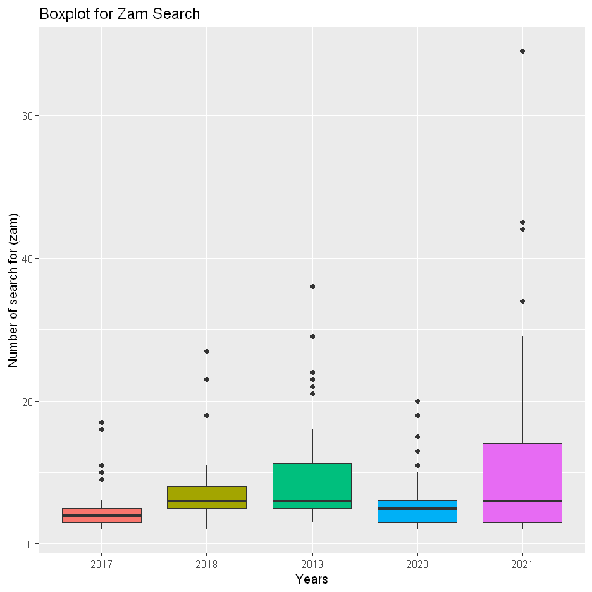

```r
ggplot(zam,aes(x=factor(year(Date)),y=zam))+ geom_boxplot(aes(fill=factor(year(Date))))+
  xlab("Years") + ylab("Number of search for (zam)")+ ggtitle("Boxplot for Zam Search")+
  theme(legend.position = "none")
```

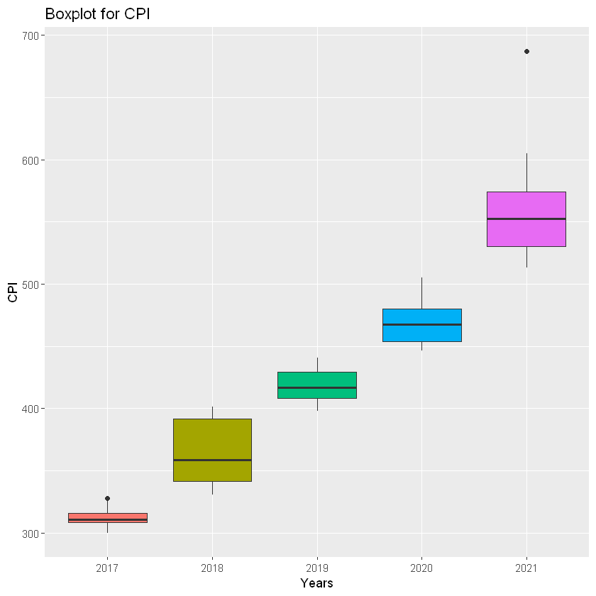

```r
ggplot(cpi,aes(x=factor(year(Tarih)),y=cpival))+ geom_boxplot(aes(fill=factor(year(Tarih))))+
  xlab("Years") + ylab("CPI")+ ggtitle("Boxplot for CPI")+
  theme(legend.position = "none")
```

In terms of mean search volume, the data does not change much, however some weeks can be said to be significant outliers, as they may point out the weeks where the cpi changes the most. Therefore, the "zam" search results can said to be mildly similar to CPI dataset.

```
'data.frame':	246 obs. of  2 variables:
 $ Date         : Factor w/ 246 levels "2017-04-16","2017-04-23",..: 1 2 3 4 5 6 7 8 9 10 ...
 $ satilik_daire: int  24 25 27 25 24 24 23 24 23 21 ...
```

[figure not shown]

```r
satilik=read.csv("satilik_search.csv")
str(satilik)
satilik$Date=as.Date(as.yearmon(satilik$Date))

satilik$Date=ymd(satilik$Date)
satilik$month_year <-format(satilik$Date,'%Y-%m')

ggplot(satilik,aes(x=factor(year(Date)),y=satilik_daire))+ geom_boxplot(aes(fill=factor(year(Date))))+
  xlab("Years") + ylab("CPI")+ ggtitle("Boxplot for CPI")+
  theme(legend.position = "none")
```

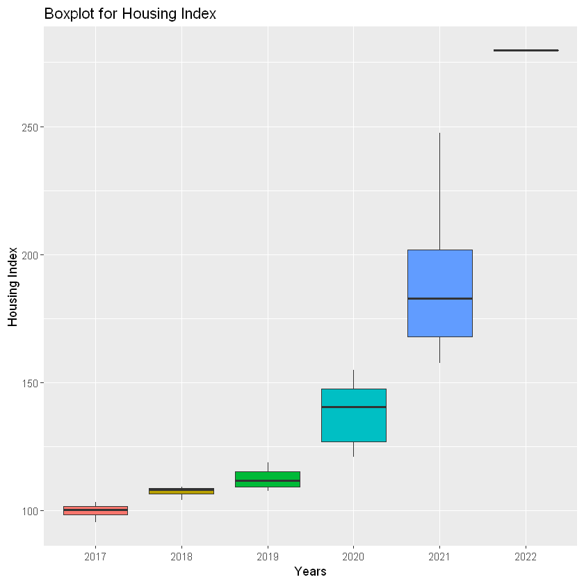

```r
ggplot(housing,aes(x=factor(year(Tarih)),y=TPHKFE01))+ geom_boxplot(aes(fill=factor(year(Tarih))))+
  xlab("Years") + ylab("Housing Index")+ ggtitle("Boxplot for Housing Index")+
  theme(legend.position = "none")
```

It is evident that the "satilik daire" search is correlated with the housing index. Therefore it can be said that the increase in demand created this increase in house prices.

```
'data.frame':	246 obs. of  2 variables:
 $ Date      : Factor w/ 246 levels "2017-04-16","2017-04-23",..: 1 2 3 4 5 6 7 8 9 10 ...
 $ bilgisayar: int  29 30 31 36 32 33 33 38 39 39 ...
```

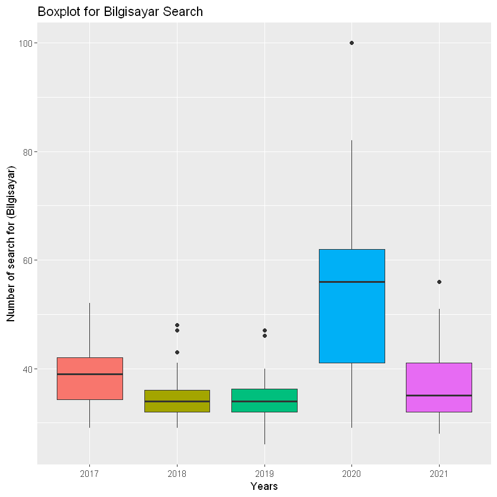

```r
computer=read.csv("bgsearch.csv")
str(computer)
computer$Date=as.Date(as.yearmon(computer$Date))

computer$Date=ymd(computer$Date)
computer$month_year <-format(computer$Date,'%Y-%m')

ggplot(computer,aes(x=factor(year(Date)),y=bilgisayar))+ geom_boxplot(aes(fill=factor(year(Date))))+
  xlab("Years") + ylab("Number of search for (Bilgisayar)")+ ggtitle("Boxplot for Bilgisayar Search")+
  theme(legend.position = "none")
```

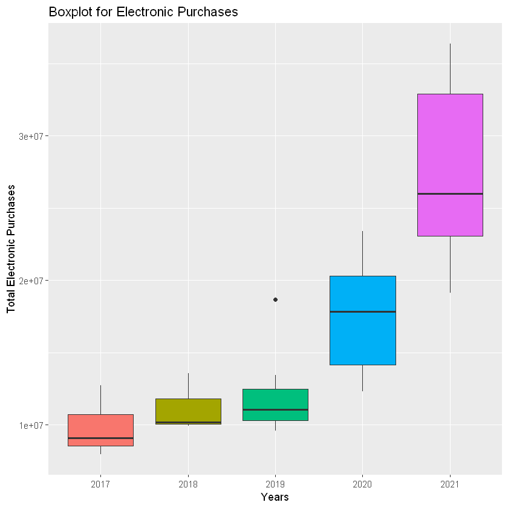

```r
ggplot(purchases,aes(x=factor(year(Date)),y=Total.Electronic.Purchases))+ geom_boxplot(aes(fill=factor(year(Date))))+
  xlab("Years") + ylab("Total Electronic Purchases")+ ggtitle("Boxplot for Electronic Purchases")+
  theme(legend.position = "none")
```

The datasets do not seem to be strongly correlated. Therefore it can be claimed that the increase in demand in electronic devices do not always translate to prices going up.